# Exercise 5

Kyle M. Lang

Fundamental Techniques in Data Science with R

We will use the following packages in this practical:

```r
library(dplyr)
library(magrittr)
library(ggplot2)
```

In this practical, you will perform regression analyses using `lm()` and create plots using `ggplot()`.

# 1 Fitting Linear Models

## 1.1

**Fit the following linear models using the `anscombe` data:**

- Predict `y1` from `x1`
  - Stored the results in an object called `fit1`
- Predict `y2` from `x2`
  - Stored the results in an object called `fit2`
- Predict `y3` from `x3`
  - Stored the results in an object called `fit3`
- Predict `y4` from `x4`
  - Stored the results in an object called `fit4`

## 1.2

**Combine/format output**

Create a 2 $\times$ 4 data frame wherein each column contains the coefficients from a different one of the four fitted models you estimated in Question 1.1.

## 1.3

**Inspect the estimates from the four models estimated in 1.1**

What do you notice about these estimates?

# 2 Visualizing Bivariate Relations

## 2.1

**Plot the pair {`x1`, `y1`}**

Use the `ggplot()` function from the **ggplot2** package to create a scatter plot wherein:

- `y1` is plotted on the Y-axis
- `x1` is plotted on the X-axis
- The color of the points is blue

## 2.2

**Visualize the four pairs of variables from 1.1 in a single plot**

Use `ggplot()` to create a single scatter plot wherein the points have the following colors:

- Blue for {`x1`, `y1`}
- Gray for {`x2`, `y2`}
- Orange for {`x3`, `y3`}
- Purple for {`x4`, `y4`}

In other words, create the following plot.

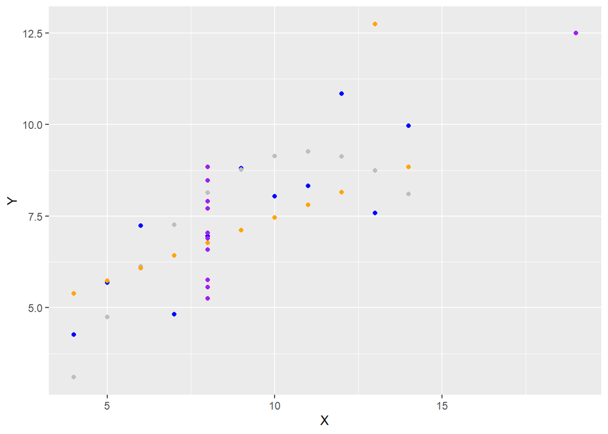

## 2.3

**Add regression lines to the plot from Question 2.2**

Use the `geom_smooth()` function to add linear regression lines with the following characteristics:

- One line for {`x3`, `y3`}
- One line for {`x4`, `y4`}
- No lines for {`x1`, `y1`} or {`x2`, `y2`}
- Assign the lines the same color as their respective points
- Don’t plot the standard error bands

## 2.4

**Add loess lines to the plot from 2.2**

Use `geom_smooth()` to add loess lines with the following characteristics:

- Add lines for *all pairs except* {`x4`, `y4`}
- Assign the lines the same color as their respective points
- Don’t plot the standard error bands

End of Exercise 5